# Understanding Pop Music in 2018

Eva Ma

11/8/2018

## Data Collection

2260 unique songs was obtained from the playlists “Today’s Top Hits”, ‘Pop Rising’, ‘Hot Rhythmic’, ‘Mega Hit Mix’, ‘New Music Friday’, ‘Hit Rewind’, ‘Teen Party’, ‘Guilty Pleasures’, ‘Women of Pop’, ‘Soft Pop Hits’, ‘African Heat’, ‘Acoustic Hits’, ‘Fresh & Chill’, ‘Bedroom Pop’, ‘Everyday Favorites’, ‘Global X’, ‘Contemporary Blend’, ‘Fangirls Run the World’, ‘Singled Out’, ‘Left of Center’, ‘Afropop’, ‘Pop Sauce’, ‘Mellow Pop’, ‘Wa-oh-wa-oh!’, ‘Out Now’, ‘Pop Royalty’, ‘Workday: Pop’, ‘Now Hear This’, ‘Certified Gold’, ‘Crowd Pleasers’, ‘LA Pops’, ‘LADY GAGA / JOANNE’, ‘Pop Matters’, ‘Retro Pop’, “Tomorrow’s Hits”, ‘All A Cappella’, ‘Yalla Araby’, ‘Persian Essentials’, ‘Radio 1 Playlist (BBC)’, ‘Wild Cards: Winter Mix’, ‘Arab X’, ‘Fresh Finds: Poptronix’, ‘The GRAMMYs Official Playlist’, ‘Pop Chile’, “Today’s Top Egyptian Hits”, “Today’s Top Maghreb Hits”.

```
##   liveness   tempo energy speechiness mode instrumentalness key
## 1   0.2760 120.966  0.768      0.0360    1         4.49e-05   8
## 2   0.1150 103.968  0.767      0.1860    0         0.00e+00   3
## 3   0.1370 113.981  0.780      0.0623    0         7.07e-06  11
## 4   0.0398  99.974  0.678      0.0514    0         2.12e-05   3
## 5   0.0505 139.943  0.545      0.0625    1         2.89e-04   2
## 6   0.1570 119.953  0.890      0.0405    0         0.00e+00   7
##   duration_ms                     id
## 1      289013 4ye3W4xNyQkIItKp01QbLM
## 2      149238 52LnBX83fvrNcG4ZMEYiHg
## 3      166174 70mNuGg5a0oRkKUuaWpWmi
## 4      265201 1Y17SjCAGNLcYZYeZ4mKiC
## 5      162586 5o4yGlG0PfeVUa6ClIyOxq
## 6      228421 5yETxZBoH5AJywvFXCUCZe
##                                     name popularity
```

[output cut: 27 more lines]

```
##   liveness   tempo energy speechiness mode instrumentalness popularity
## 1   0.2760 120.966  0.768      0.0360    1         4.49e-05         45
## 2   0.1150 103.968  0.767      0.1860    0         0.00e+00         23
## 3   0.1370 113.981  0.780      0.0623    0         7.07e-06         47
## 4   0.0398  99.974  0.678      0.0514    0         2.12e-05         27
## 5   0.0505 139.943  0.545      0.0625    1         2.89e-04         72
## 6   0.1570 119.953  0.890      0.0405    0         0.00e+00         37
##   acousticness loudness valence danceability
## 1     2.99e-05   -6.211  0.0986        0.645
## 2     4.30e-01   -2.073  0.8900        0.784
## 3     2.17e-01   -4.313  0.5500        0.745
## 4     2.50e-01   -7.162  0.8410        0.820
## 5     6.46e-02   -5.192  0.5250        0.867
## 6     2.63e-03   -5.016  0.3820        0.587
```

```
## [1] 20.64241
```

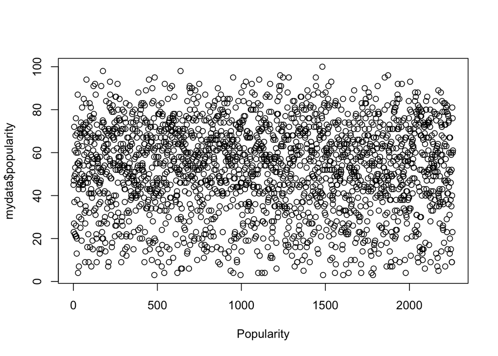

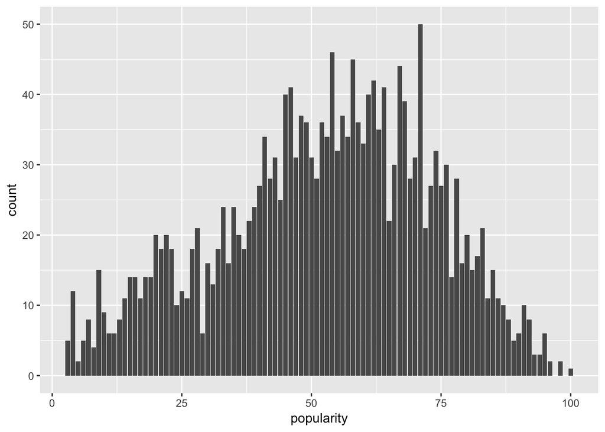

The data set covers a range of popularities with a standard deviation of 20.64241. The data set is slightly more centered towards the right tail.

The data set is split into a training set and a testings set.

## Naive MLR Model

To investigate what factors influence a song’s popularity, we first run a naive MLR model, where the regressors are energy, valence, liveness, tempo, speechiness, instrumentalness, acousticness, loudness, and danceability.

```
##
## Call:
## lm(formula = popularity ~ energy + valence + liveness + tempo +
##     speechiness + instrumentalness + acousticness + loudness +
##     danceability)
##
## Residuals:
##     Min      1Q  Median      3Q     Max
## -61.795 -13.490   1.701  14.663  49.899
##
## Coefficients:
##                    Estimate Std. Error t value Pr(>|t|)
## (Intercept)       7.496e+01  5.121e+00  14.637  < 2e-16 ***
## energy           -1.790e+01  4.207e+00  -4.254 2.19e-05 ***
## valence          -1.646e+01  2.374e+00  -6.933 5.53e-12 ***
## liveness         -8.647e+00  3.312e+00  -2.611  0.00911 **
## tempo            -2.375e-04  1.629e-02  -0.015  0.98837
## speechiness       2.112e+00  5.426e+00   0.389  0.69718
## instrumentalness -1.631e+00  3.987e+00  -0.409  0.68257
## acousticness     -8.506e+00  2.164e+00  -3.931 8.76e-05 ***
## loudness          1.878e+00  2.516e-01   7.463 1.26e-13 ***
## danceability      2.138e+01  3.539e+00   6.042 1.82e-09 ***
## ---
## Signif. codes:  0 '***' 0.001 '**' 0.01 '*' 0.05 '.' 0.1 ' ' 1
##
## Residual standard error: 19.71 on 1990 degrees of freedom
## Multiple R-squared:  0.09236,    Adjusted R-squared:  0.08825
## F-statistic:  22.5 on 9 and 1990 DF,  p-value: < 2.2e-16
```

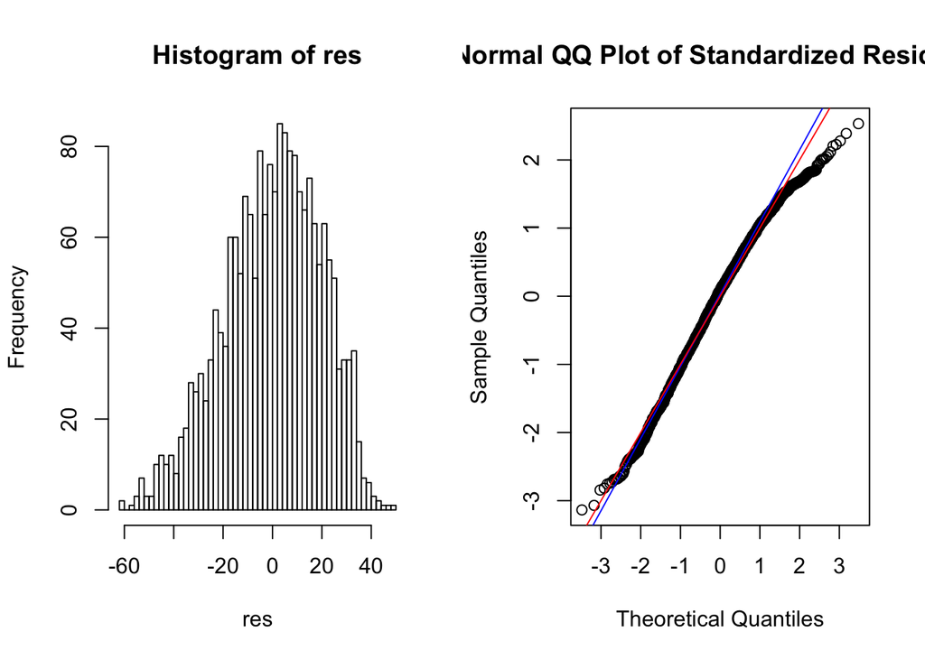

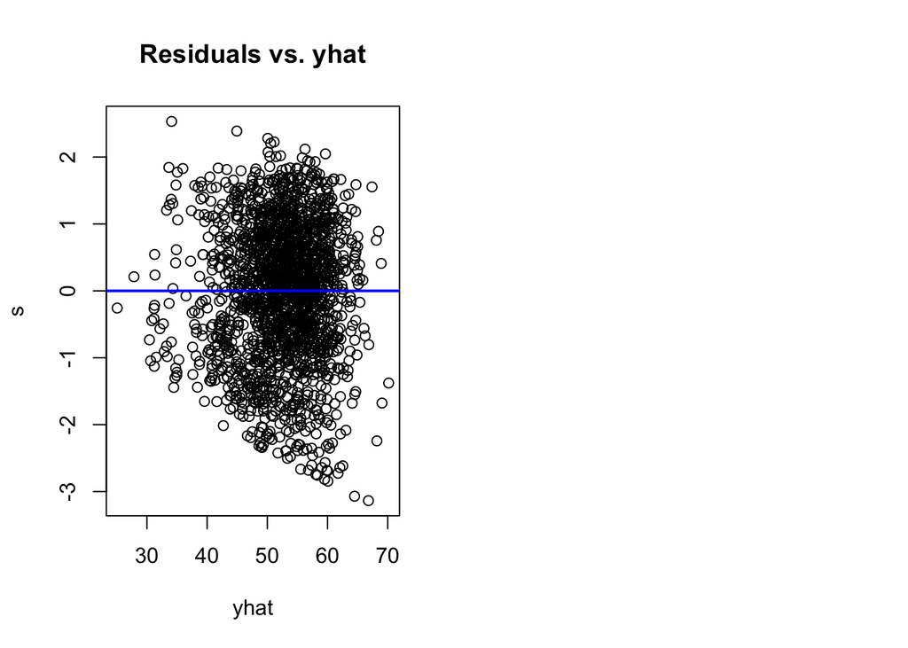

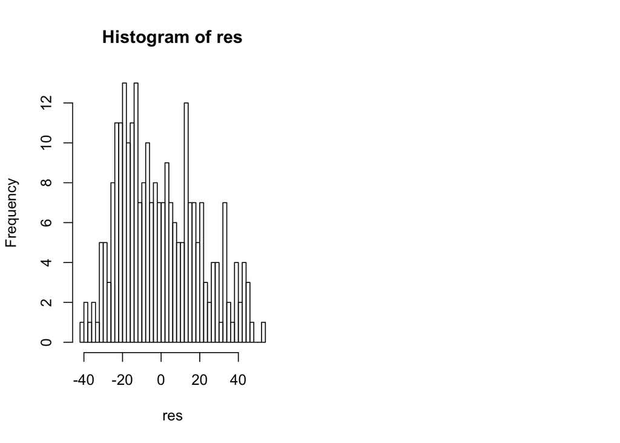

The estimates indicate that there is a negative relationship between popularity and energy, valence, liveness, tempo, instrumentalness, acousticness. Most of the results make sense. For example, generally, people prefer to play music recorded in studios, so songs with low liveness are more popular. In 2018, popular music is increasingly electronic, so it makes sense that acousticness have a negative coefficient. Also, catchy music often have lyrics, which results in a low instrumentalness.

However, it is unclear why energy, valence, and tempo also have negative coeffients. It is assumed that generally pop music is energetic and happy.

In terms of standard error of each estimates, it is very small and therefore desired. It follows that most estimates are highly significant, except for tempo, speechiness, and instrumentalness.

The $R^2$ value is relatively small, which means that only a small portion of the variablity in observations is explained by this model.

Our F statistics, however, is high significant. It shows that our model is highly significant.

Next, we will focus on improving the $R^2$ value.

## A Closer Look at the Dataset - Visualization

Let’s first visualization the distrubution of the regressor speechiness, tempo and instrumentalness.

Below is a histogram for the distribution of speechiness, danceability, energy, liveness, valence, and instrumentalness.

We can see that speechiness, instrumentalness, acousticness, and liveness are heavily centered around 0.

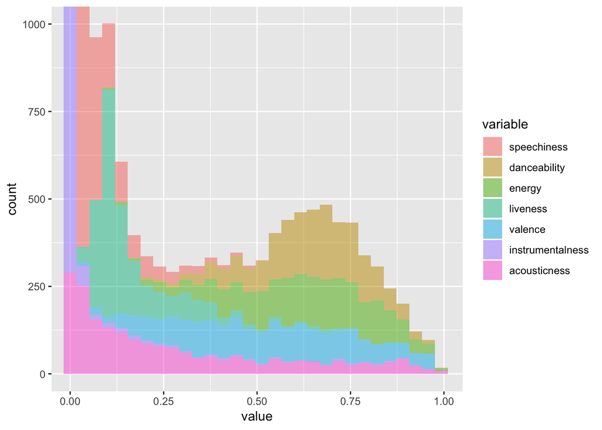

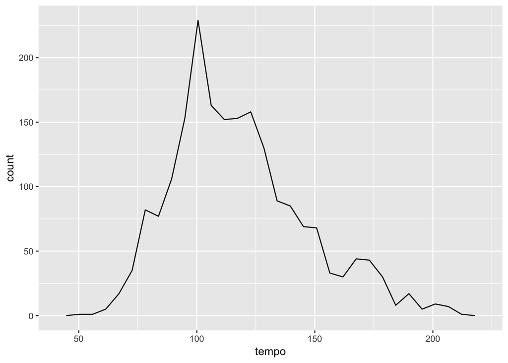

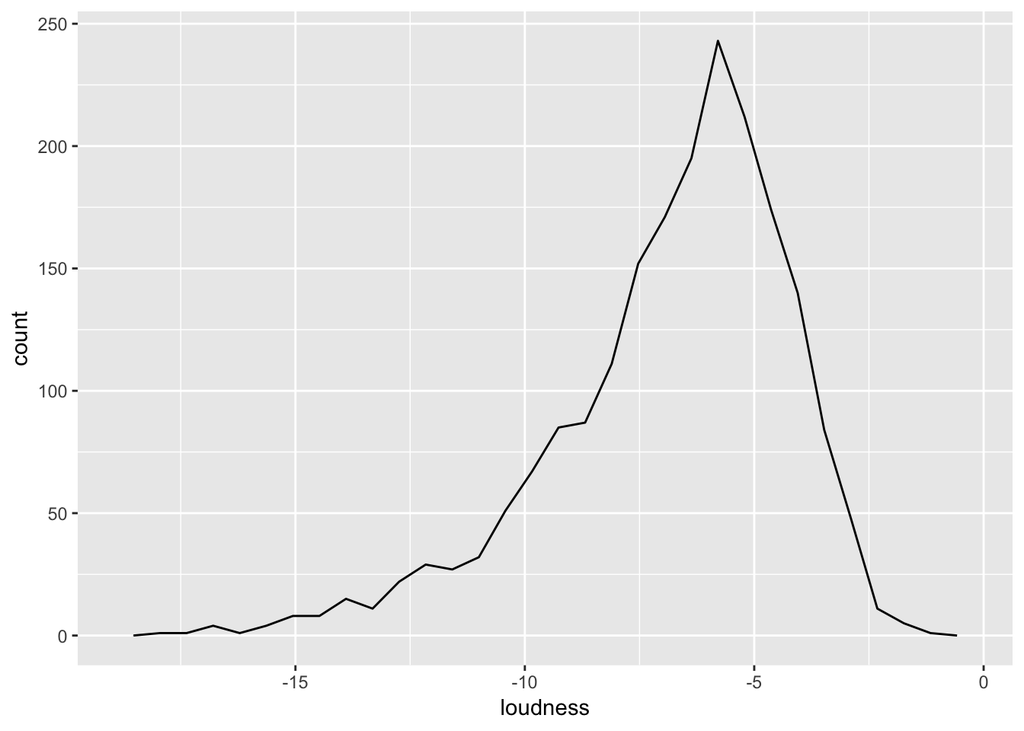

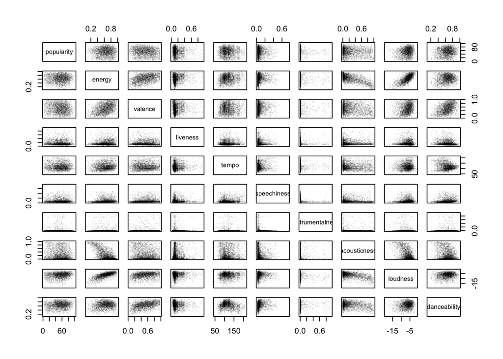

## Are the variables correlated?

```
##                       energy    valence    liveness       tempo
## energy            1.00000000  0.3727164  0.11254158  0.11004218
## valence           0.37271641  1.0000000  0.02685500  0.01175350
## liveness          0.11254158  0.0268550  1.00000000  0.01089756
## tempo             0.11004218  0.0117535  0.01089756  1.00000000
## speechiness       0.11249669  0.1295321  0.02714273  0.11784701
## instrumentalness -0.04463278 -0.0103007 -0.00895431  0.02546522
## acousticness     -0.63203800 -0.1625865 -0.03123947 -0.07336780
## loudness          0.70101084  0.2111887  0.04728143  0.05572854
## danceability      0.11929062  0.4049074 -0.08808117 -0.16440472
##                  speechiness instrumentalness acousticness    loudness
## energy            0.11249669      -0.04463278  -0.63203800  0.70101084
## valence           0.12953212      -0.01030070  -0.16258652  0.21118869
## liveness          0.02714273      -0.00895431  -0.03123947  0.04728143
## tempo             0.11784701       0.02546522  -0.07336780  0.05572854
## speechiness       1.00000000      -0.06465612  -0.07627825  0.04038528
## instrumentalness -0.06465612       1.00000000   0.03509993 -0.19519831
## acousticness     -0.07627825       0.03509993   1.00000000 -0.50335926
## loudness          0.04038528      -0.19519831  -0.50335926  1.00000000
## danceability      0.10034899       0.00391788  -0.22994586  0.13646074
##                  danceability
## energy             0.11929062
## valence            0.40490736
## liveness          -0.08808117
## tempo             -0.16440472
## speechiness        0.10034899
## instrumentalness   0.00391788
## acousticness      -0.22994586
## loudness           0.13646074
## danceability       1.00000000
```

```
##           energy          valence         liveness            tempo
##         2.995352         1.450687         1.027293         1.069369
##      speechiness instrumentalness     acousticness         loudness
##         1.051210         1.067450         1.823955         2.143040
##     danceability
##         1.367619
```

## Log Transformation

From the plots above, we can see a few regressors are not normally distributed like liveness and speechiness. A log transformation is applied to both variables.

```
##
## Call:
## lm(formula = popularity ~ energy + valence + log(liveness) +
##     tempo + log(speechiness) + instrumentalness + acousticness +
##     loudness + danceability)
##
## Residuals:
##     Min      1Q  Median      3Q     Max
## -61.569 -13.641   1.703  14.688  48.926
##
## Coefficients:
##                    Estimate Std. Error t value Pr(>|t|)
## (Intercept)       7.079e+01  5.998e+00  11.803  < 2e-16 ***
## energy           -1.796e+01  4.219e+00  -4.258 2.15e-05 ***
## valence          -1.657e+01  2.373e+00  -6.984 3.89e-12 ***
## log(liveness)    -2.099e+00  7.303e-01  -2.875 0.004089 **
## tempo            -7.678e-04  1.630e-02  -0.047 0.962426
## log(speechiness)  3.214e-01  6.611e-01   0.486 0.626892
## instrumentalness -1.745e+00  3.990e+00  -0.437 0.661914
## acousticness     -8.384e+00  2.164e+00  -3.874 0.000111 ***
## loudness          1.885e+00  2.514e-01   7.496 9.85e-14 ***
## danceability      2.103e+01  3.569e+00   5.893 4.44e-09 ***
## ---
## Signif. codes:  0 '***' 0.001 '**' 0.01 '*' 0.05 '.' 0.1 ' ' 1
##
## Residual standard error: 19.7 on 1990 degrees of freedom
## Multiple R-squared:  0.09304,    Adjusted R-squared:  0.08894
## F-statistic: 22.68 on 9 and 1990 DF,  p-value: < 2.2e-16
```

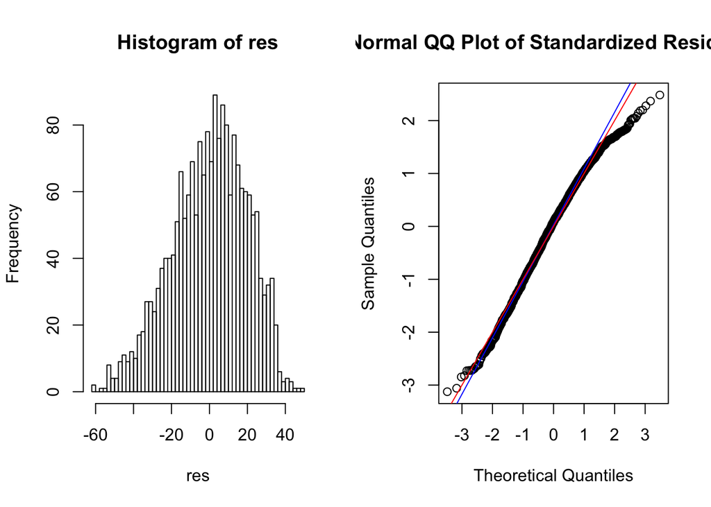

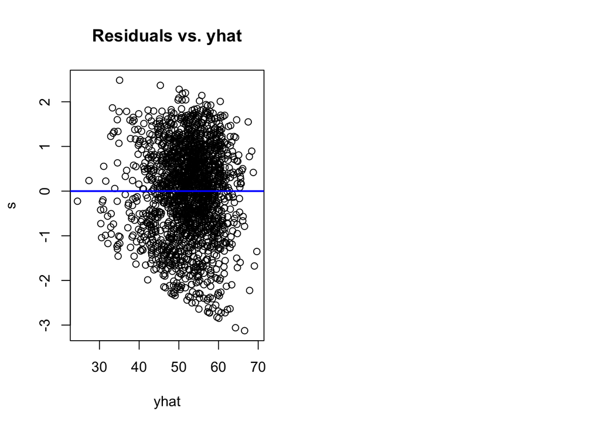

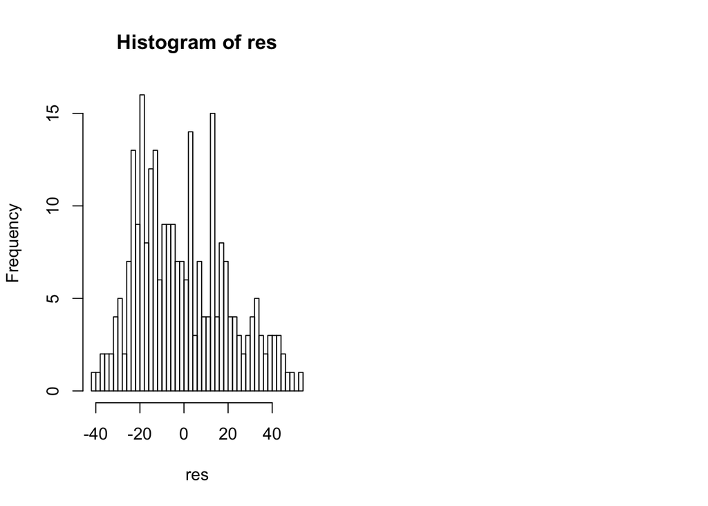

As we can see,
$$R^2$$
improved while maintaining a significant model.

## Categorical Analysis

```
## F
##    0    1
##  818 1182
```

```
##
## Call:
## lm(formula = popularity ~ energy + valence + log(liveness) +
##     tempo + log(speechiness) + instrumentalness + acousticness +
##     loudness + danceability + mode)
##
## Residuals:
##     Min      1Q  Median      3Q     Max
## -62.395 -13.100   1.589  14.610  48.775
##
## Coefficients:
##                    Estimate Std. Error t value Pr(>|t|)
## (Intercept)       68.586966   6.014374  11.404  < 2e-16 ***
## energy           -17.271985   4.211500  -4.101 4.28e-05 ***
## valence          -16.417590   2.366300  -6.938 5.36e-12 ***
## log(liveness)     -1.982862   0.729051  -2.720 0.006589 **
## tempo             -0.001482   0.016252  -0.091 0.927366
## log(speechiness)   0.511273   0.661499   0.773 0.439673
## instrumentalness  -1.761740   3.978619  -0.443 0.657957
## acousticness      -8.513844   2.158542  -3.944 8.28e-05 ***
## loudness           1.831122   0.251170   7.290 4.44e-13 ***
## danceability      21.558249   3.561972   6.052 1.70e-09 ***
## mode               3.154384   0.904068   3.489 0.000495 ***
## ---
## Signif. codes:  0 '***' 0.001 '**' 0.01 '*' 0.05 '.' 0.1 ' ' 1
##
## Residual standard error: 19.65 on 1989 degrees of freedom
## Multiple R-squared:  0.09856,    Adjusted R-squared:  0.09403
## F-statistic: 21.75 on 10 and 1989 DF,  p-value: < 2.2e-16
```

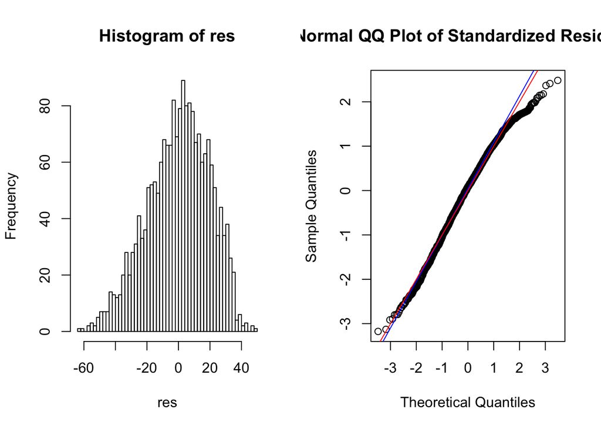

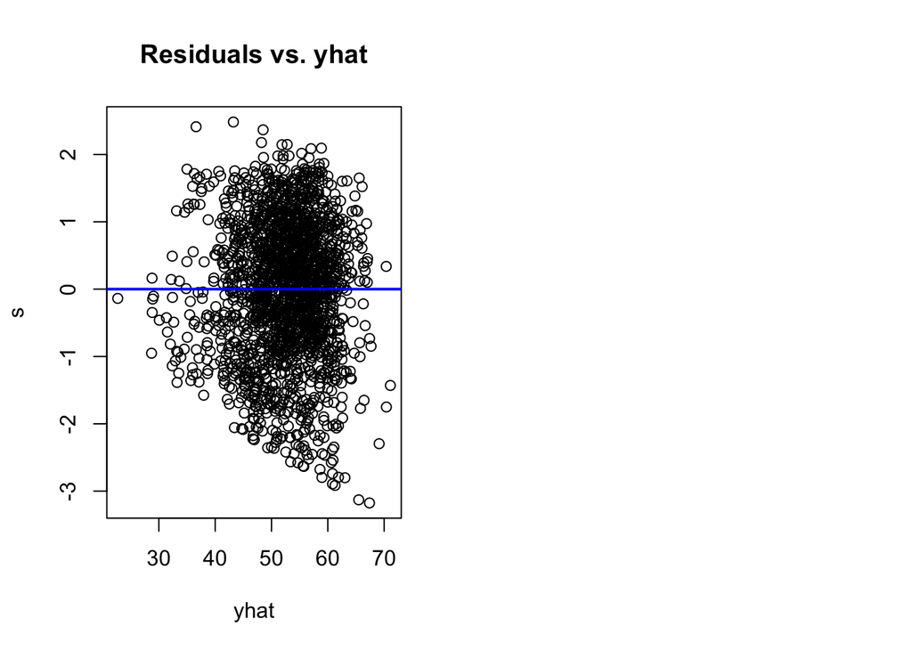

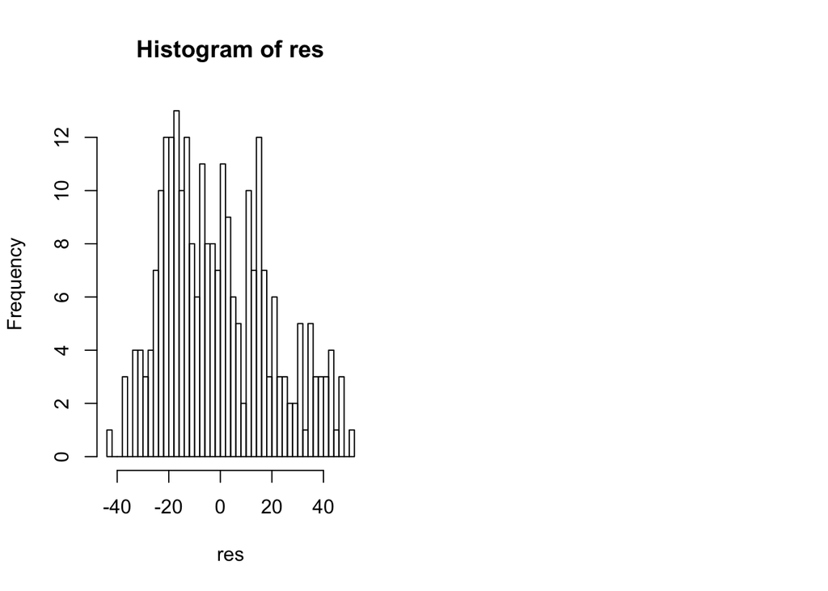

The difference between the popularity of a song resulting from changing from a minor scale to a major scale is 3.15.

## Removing insignificant variables

```
##
## Call:
## lm(formula = popularity ~ energy + valence + acousticness + loudness +
##     danceability)
##
## Residuals:
##     Min      1Q  Median      3Q     Max
## -61.915 -13.299   1.832  14.833  51.036
##
## Coefficients:
##              Estimate Std. Error t value Pr(>|t|)
## (Intercept)   74.0745     4.5718  16.203  < 2e-16 ***
## energy       -19.0660     4.1461  -4.599 4.52e-06 ***
## valence      -16.4921     2.3691  -6.961 4.56e-12 ***
## acousticness  -8.6428     2.1619  -3.998 6.62e-05 ***
## loudness       1.9173     0.2442   7.852 6.61e-15 ***
## danceability  22.2484     3.4496   6.450 1.40e-10 ***
## ---
## Signif. codes:  0 '***' 0.001 '**' 0.01 '*' 0.05 '.' 0.1 ' ' 1
##
## Residual standard error: 19.73 on 1994 degrees of freedom
## Multiple R-squared:  0.08912,    Adjusted R-squared:  0.08683
## F-statistic: 39.02 on 5 and 1994 DF,  p-value: < 2.2e-16
```

## GLM

```
##
## Call:
## glm(formula = mydata$popularity ~ mydata$energy + mydata$valence +
##     mydata$speechiness + mydata$instrumentalness + mydata$acousticness +
##     mydata$loudness + mydata$danceability, family = gaussian(link = "log"))
##
## Deviance Residuals:
##     Min       1Q   Median       3Q      Max
## -63.851  -13.709    1.903   15.391   47.672
##
## Coefficients:
##                          Estimate Std. Error t value Pr(>|t|)
## (Intercept)              4.409263   0.085565  51.531  < 2e-16 ***
## mydata$energy           -0.397678   0.076431  -5.203 2.14e-07 ***
## mydata$valence          -0.291551   0.042605  -6.843 9.96e-12 ***
## mydata$speechiness       0.038799   0.098388   0.394    0.693
## mydata$instrumentalness -0.096322   0.081155  -1.187    0.235
## mydata$acousticness     -0.165406   0.040118  -4.123 3.88e-05 ***
## mydata$loudness          0.036867   0.004797   7.685 2.26e-14 ***
## mydata$danceability      0.376002   0.062913   5.977 2.64e-09 ***
## ---
## Signif. codes:  0 '***' 0.001 '**' 0.01 '*' 0.05 '.' 0.1 ' ' 1
##
## (Dispersion parameter for gaussian family taken to be 395.5834)
##
##     Null deviance: 972090  on 2258  degrees of freedom
## Residual deviance: 890453  on 2251  degrees of freedom
## AIC: 19930
##
## Number of Fisher Scoring iterations: 5
```

## Ridge, LASSO, and Elastic Net Models

```
## [1] 0.4039334
```

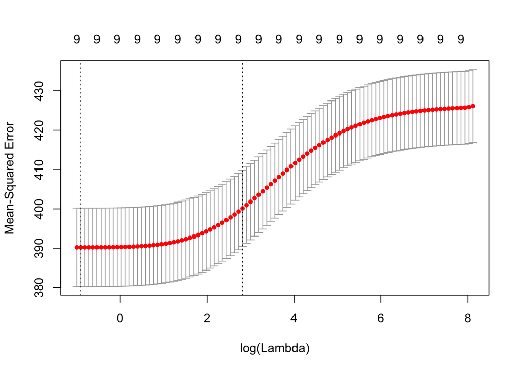

```
## 10 x 1 sparse Matrix of class "dgCMatrix"
##                             1
## (Intercept)      59.699079299
## energy           -2.902208411
## valence          -7.929216204
## liveness         -6.080651341
## tempo            -0.006363004
## speechiness      -0.059816851
## instrumentalness -3.247569282
## acousticness     -4.441581218
## loudness          0.701575494
## danceability     10.276474345
```

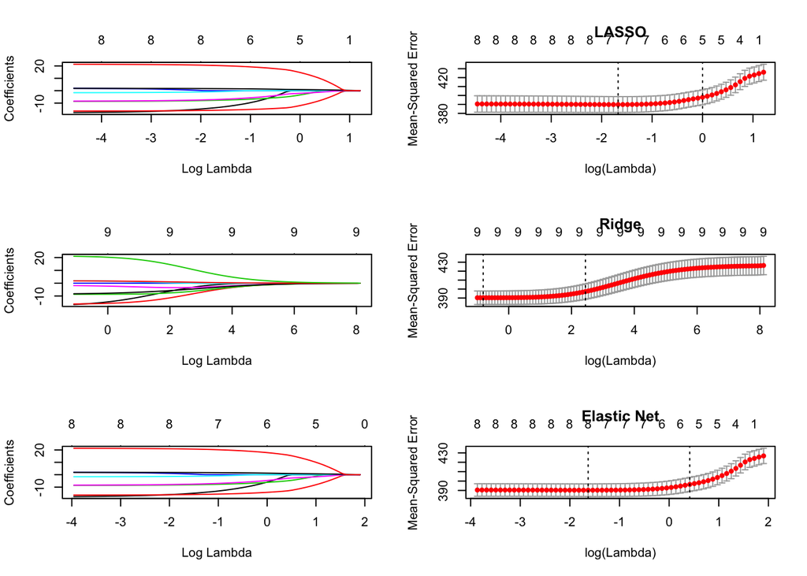

```
## 11 x 1 sparse Matrix of class "dgCMatrix"
##                              1
## (Intercept)       70.199752834
## liveness          -8.169952659
## tempo             -0.001514498
## energy           -15.498447640
## speechiness        2.982391537
## mode               3.101716006
## instrumentalness  -2.025427072
## acousticness      -8.284175632
## loudness           1.718498175
## valence          -15.972480994
## danceability      21.433698845
```

```
##       RMSE    Rsquare
## 1 20.68306 0.07863005
```

```
## 11 x 1 sparse Matrix of class "dgCMatrix"
##                           1
## (Intercept)       69.818689
## liveness          -7.736930
## tempo              .
## energy           -15.150653
## speechiness        1.917627
## mode               2.984706
## instrumentalness  -1.322010
## acousticness      -7.954428
## loudness           1.729213
## valence          -16.005359
## danceability      21.517975
```

```
##       RMSE    Rsquare
## 1 20.69668 0.07740485
```

```
## 11 x 1 sparse Matrix of class "dgCMatrix"
##                           1
## (Intercept)       69.530641
## liveness          -7.666020
## tempo              .
## energy           -14.827475
## speechiness        1.690240
## mode               2.956563
## instrumentalness  -1.253461
## acousticness      -7.843299
## loudness           1.713680
## valence          -15.946253
## danceability      21.427736
```

```
##       RMSE    Rsquare
## 1 20.69968 0.07707649
```

```
##
## Call:
## summary.resamples(object = ., metric = "RMSE")
##
## Models: ridge, lasso, elastic
## Number of resamples: 10
##
## RMSE
##             Min.  1st Qu.   Median     Mean  3rd Qu.     Max. NA's
## ridge   18.95893 19.30419 19.57309 19.69751 20.20207 20.39854    0
## lasso   18.62187 19.09699 19.67045 19.67089 19.89849 21.46135    0
## elastic 18.32419 19.62304 19.93524 19.71031 20.13583 20.26924    0
```